# MM

2025-10-05

#Downloaded two datasets from GitHub into my working directory and verified that they are saved by listing the directory contents.

```r
# Part 1

# Download inputs from the assignment repo (tip: 'view raw' then copy URL)
download.file("https://github.com/ghazkha/Assessment4/raw/main/gene_expression.tsv",
              destfile = "gene_expression.tsv", quiet = TRUE)

download.file("https://github.com/ghazkha/Assessment4/raw/main/growth_data.csv",
              destfile = "growth_data.csv", quiet = TRUE)

list.files()
```

```
##  [1] "Assignment-4.Rproj"  "ecoli_cds.fa"        "gene_expression.tsv"
##  [4] "growth_data.csv"     "LICENSE"             "MMM_files"
##  [7] "MMM.html"            "MMM.Rmd"             "README.md"
## [10] "salmonella_cds.fa"
```

#Q1 I read the gene expression table (`gene_expression.tsv`) with the first column of gene IDs set as row names and then displayed the first six rows using `head(gene_data)`. The output shows raw integer counts for each gene across three samples. Most genes have low or zero counts, while some like *WASH7P* show relatively high expression, indicating variability in transcription levels between genes and across samples.

```r
# Q1: read TSV, gene IDs as row names
gene_data <- read.table("gene_expression.tsv",
                        header = TRUE,
                        row.names = 1,
                        sep = "\t")
head(gene_data)  # first six genes
```

```
##                               GTEX.1117F.0226.SM.5GZZ7 GTEX.1117F.0426.SM.5EGHI
## ENSG00000223972.5_DDX11L1                            0                        0
## ENSG00000227232.5_WASH7P                           187                      109
## ENSG00000278267.1_MIR6859-1                          0                        0
## ENSG00000243485.5_MIR1302-2HG                        1                        0
## ENSG00000237613.2_FAM138A                            0                        0
## ENSG00000268020.3_OR4G4P                             0                        1
##                               GTEX.1117F.0526.SM.5EGHJ
## ENSG00000223972.5_DDX11L1                            0
## ENSG00000227232.5_WASH7P                           143
## ENSG00000278267.1_MIR6859-1                          1
## ENSG00000243485.5_MIR1302-2HG                        0
## ENSG00000237613.2_FAM138A                            0
## ENSG00000268020.3_OR4G4P                             0
```

#Q2 I selected all numeric sample columns with `sapply(..., is.numeric)`, computed the row‐wise mean using `rowMeans`, and appended it as a new column `mean_expression`, then previewed the first six rows. In the output, I now see an extra column at the far right (so the viewer shows “1–3 of 4 columns”), giving each gene’s average count across the samples—most genes have means near zero, while genes like **WASH7P** have a much higher mean, reflecting stronger expression.

```r
# Q2: add mean of the other (numeric) columns
num_cols <- sapply(gene_data, is.numeric)
gene_data$mean_expression <- rowMeans(gene_data[, num_cols, drop = FALSE])
head(gene_data)
```

```
##                               GTEX.1117F.0226.SM.5GZZ7 GTEX.1117F.0426.SM.5EGHI
## ENSG00000223972.5_DDX11L1                            0                        0
## ENSG00000227232.5_WASH7P                           187                      109
## ENSG00000278267.1_MIR6859-1                          0                        0
## ENSG00000243485.5_MIR1302-2HG                        1                        0
## ENSG00000237613.2_FAM138A                            0                        0
## ENSG00000268020.3_OR4G4P                             0                        1
##                               GTEX.1117F.0526.SM.5EGHJ mean_expression
## ENSG00000223972.5_DDX11L1                            0       0.0000000
## ENSG00000227232.5_WASH7P                           143     146.3333333
## ENSG00000278267.1_MIR6859-1                          1       0.3333333
## ENSG00000243485.5_MIR1302-2HG                        0       0.3333333
## ENSG00000237613.2_FAM138A                            0       0.0000000
## ENSG00000268020.3_OR4G4P                             0       0.3333333
```

#Q3 I ordered the genes by descending `mean_expression` and pulled the first ten rows, then printed them. The output shows the top-10 most highly expressed genes across samples—mostly mitochondrial genes (MT-CO1, MT-ND4, MT-CO3, MT-ND1, MT-ATP6, MT-CYB, MT-ND2, MT-CO2) along with **GPX3** and **EEF1A1**—with very large counts. I also see that the second sample (5EGHI) is generally higher than the first (5GZZ7), suggesting between-sample expression differences.

```r
# Q3: Top 10 by mean
sorted_genes <- gene_data[order(-gene_data$mean_expression), ]
top_10_genes <- head(sorted_genes, 10)
top_10_genes
```

```
##                           GTEX.1117F.0226.SM.5GZZ7 GTEX.1117F.0426.SM.5EGHI
## ENSG00000198804.2_MT-CO1                    267250                  1101779
## ENSG00000198886.2_MT-ND4                    273188                   991891
## ENSG00000198938.2_MT-CO3                    250277                  1041376
## ENSG00000198888.2_MT-ND1                    243853                   772966
## ENSG00000198899.2_MT-ATP6                   141374                   696715
## ENSG00000198727.2_MT-CYB                    127194                   638209
## ENSG00000198763.3_MT-ND2                    159303                   543786
## ENSG00000211445.11_GPX3                     464959                    39396
## ENSG00000198712.1_MT-CO2                    128858                   545360
## ENSG00000156508.17_EEF1A1                   317642                    39573
##                           GTEX.1117F.0526.SM.5EGHJ mean_expression
## ENSG00000198804.2_MT-CO1                    218923        529317.3
## ENSG00000198886.2_MT-ND4                    277628        514235.7
## ENSG00000198938.2_MT-CO3                    223178        504943.7
## ENSG00000198888.2_MT-ND1                    194032        403617.0
## ENSG00000198899.2_MT-ATP6                   151166        329751.7
## ENSG00000198727.2_MT-CYB                    141359        302254.0
## ENSG00000198763.3_MT-ND2                    149564        284217.7
## ENSG00000211445.11_GPX3                     306070        270141.7
## ENSG00000198712.1_MT-CO2                    122816        265678.0
## ENSG00000156508.17_EEF1A1                   339347        232187.3
```

#Q4 I counted how many genes have an average expression < 10 across samples using `sum(gene_data$mean_expression < 10)` and got **35,988** genes, indicating a very sparse dataset where most genes are lowly expressed or not detected.

```r
# Q4: Count genes with mean < 10
sum(gene_data$mean_expression < 10)
```

```
## [1] 35988
```

#Q5 I plotted a histogram of the `mean_expression` values for all genes to visualize their distribution. The plot shows that the vast majority of genes cluster near zero, producing a tall bar at the left edge of the graph. Only a small fraction of genes have very high expression values, which appear as a long right tail on the x-axis. This confirms what we saw earlier: most genes are expressed at low levels, while a few, like mitochondrial and housekeeping genes, dominate the total expression.

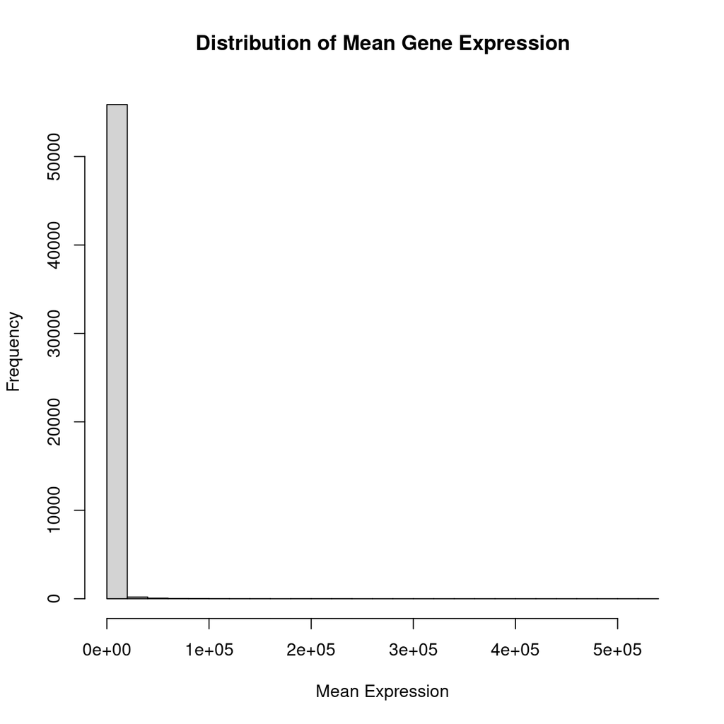

```r
# Q5: Histogram of mean values
hist(gene_data$mean_expression,
     xlab = "Mean Expression",
     ylab = "Frequency",
     main = "Distribution of Mean Gene Expression",
     breaks = 30)
```

#Q6 I loaded `growth_data.csv` into a data frame and listed its columns. The dataset has a site label and tree identifier (`Site`, `TreeID`) plus trunk circumference measurements in centimeters for four censuses: `Circumf_2005_cm`, `Circumf_2010_cm`, `Circumf_2015_cm`, and `Circumf_2020_cm`.

```r
# Q6: Read the growth CSV
growth_data <- read.csv("growth_data.csv")
colnames(growth_data)
```

```
## [1] "Site"            "TreeID"          "Circumf_2005_cm" "Circumf_2010_cm"
## [5] "Circumf_2015_cm" "Circumf_2020_cm"
```

#I examined the structure of `growth_data` and found it contains 100 observations with 6 variables. The dataset includes the site and tree ID, along with trunk circumference measurements (in cm) recorded at four time points: 2005, 2010, 2015, and 2020. Each row represents a single tree, showing its location and growth progression across years.

```r
str(growth_data)
```

```
## 'data.frame':    100 obs. of  6 variables:
##  $ Site           : chr  "northeast" "southwest" "southwest" "northeast" ...
##  $ TreeID         : chr  "A012" "A039" "A010" "A087" ...
##  $ Circumf_2005_cm: num  5.2 4.9 3.7 3.8 3.8 5.9 4.4 5.3 7.1 3.8 ...
##  $ Circumf_2010_cm: num  10.1 9.6 7.3 6.5 6.4 10 9.9 9 12 7.4 ...
##  $ Circumf_2015_cm: num  19.9 18.9 14.3 10.9 10.9 16.8 22.2 15.2 20.2 14.5 ...
##  $ Circumf_2020_cm: num  38.9 37 28.1 18.5 18.4 28.4 50 25.8 34.2 28.4 ...
```

#Q7 I calculated the average circumference and its standard deviation for trees in each site at the beginning (2005) and the end (2020). In 2005, the northeast site had slightly larger trees on average (≈ 5.29 cm) compared to the southwest (≈ 4.86 cm), with low variability. By 2020, both sites showed substantial growth: northeast trees averaged ≈ 54.2 cm and southwest trees ≈ 45.6 cm. The standard deviations also rose (≈ 25.2 in northeast, ≈ 17.9 in southwest), showing that tree sizes became more variable over time.

```r
# Q7: Mean and SD at start (2005) and end (2020)
mean_start <- tapply(growth_data$Circumf_2005_cm, growth_data$Site, mean)
sd_start   <- tapply(growth_data$Circumf_2005_cm, growth_data$Site, sd)
mean_end   <- tapply(growth_data$Circumf_2020_cm, growth_data$Site, mean)
sd_end     <- tapply(growth_data$Circumf_2020_cm, growth_data$Site, sd)

data.frame(
  Site = names(mean_start),
  Mean_2005 = as.numeric(mean_start),
  SD_2005   = as.numeric(sd_start),
  Mean_2020 = as.numeric(mean_end),
  SD_2020   = as.numeric(sd_end),
  row.names = NULL
)
```

```
##        Site Mean_2005   SD_2005 Mean_2020  SD_2020
## 1 northeast     5.292 0.9140267    54.228 25.22795
## 2 southwest     4.862 1.1474710    45.596 17.87345
```

#Q8 I made boxplots comparing tree circumferences at the start (2005) and end (2020) of the study for both northeast and southwest sites.The plot shows that in 2005, trees at both sites had very small circumferences, tightly clustered around 5 cm. By 2020, the distributions had shifted dramatically upward: northeast trees reached higher median values and displayed a wider spread (greater variability), while southwest trees also grew substantially but remained somewhat smaller on average. This visualization highlights strong overall growth over 15 years, with northeast trees tending to become both larger and more variable in size compared to southwest trees.

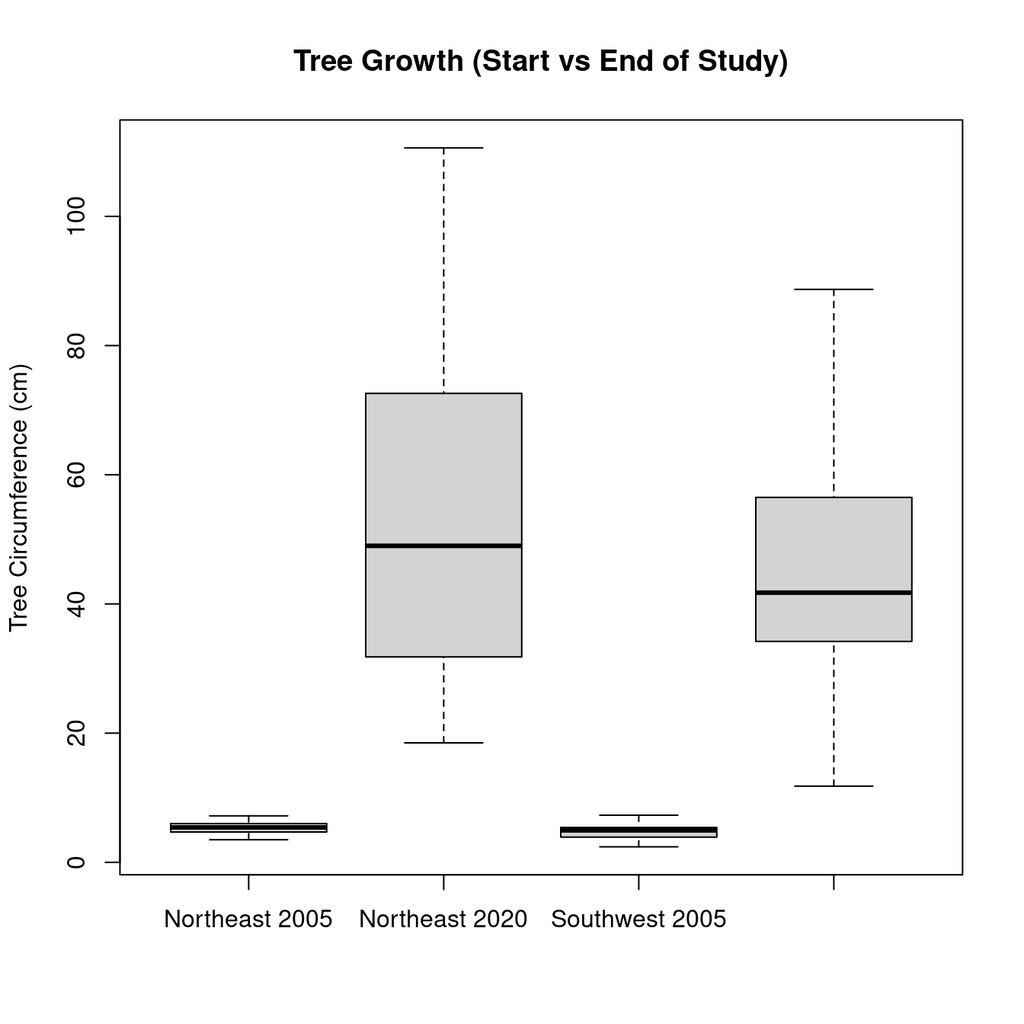

```r
# Q8: Boxplot — start vs end of study (2005 vs 2020) at both sites
boxplot(
  growth_data$Circumf_2005_cm[growth_data$Site == "northeast"],
  growth_data$Circumf_2020_cm[growth_data$Site == "northeast"],
  growth_data$Circumf_2005_cm[growth_data$Site == "southwest"],
  growth_data$Circumf_2020_cm[growth_data$Site == "southwest"],
  names = c("Northeast 2005", "Northeast 2020", "Southwest 2005", "Southwest 2020"),
  ylab = "Tree Circumference (cm)",
  main = "Tree Growth (Start vs End of Study)"
)
```

#Q9 I calculated the average 10-year growth in tree circumference (2010 → 2020) for each site. The results show that **northeast trees grew on average about 42.94 cm**, while **southwest trees grew about 35.49 cm** over the same period. This indicates that trees in the northeast site had faster growth on average compared to those in the southwest.

```r
# Q9: Mean 10-year growth by site (2010 → 2020)
growth_data$growth_10yr <- growth_data$Circumf_2020_cm - growth_data$Circumf_2010_cm
northeast_growth_mean <- mean(growth_data$growth_10yr[growth_data$Site == "northeast"], na.rm = TRUE)
southwest_growth_mean <- mean(growth_data$growth_10yr[growth_data$Site == "southwest"], na.rm = TRUE)
c(Northeast_mean_10yr = northeast_growth_mean,
  Southwest_mean_10yr = southwest_growth_mean)
```

```
## Northeast_mean_10yr Southwest_mean_10yr
##               42.94               35.49
```

#Q10 I performed a Welch two-sample t-test to compare 10-year growth between sites. The results show that northeast trees grew more on average (42.94 cm) than southwest trees (35.49 cm). The test statistic was t = 1.89 with a p-value of 0.062, and the 95% confidence interval for the difference spanned from about -0.39 to 15.29. Since the p-value is slightly above 0.05, the difference in growth between sites is not statistically significant, though there is a clear trend toward greater growth in the northeast.

```r
# Q10: t-test on 10-year growth
df <- na.omit(growth_data[, c("Site", "growth_10yr")])

t_res <- t.test(growth_10yr ~ Site, data = df)
t_res
```

```
##
##  Welch Two Sample t-test
##
## data:  growth_10yr by Site
## t = 1.8882, df = 87.978, p-value = 0.06229
## alternative hypothesis: true difference in means between group northeast and group southwest is not equal to 0
## 95 percent confidence interval:
##  -0.3909251 15.2909251
## sample estimates:
## mean in group northeast mean in group southwest
##                   42.94                   35.49
```

#I loaded the needed packages—**seqinr** for sequence analysis and **R.utils** for utilities like `gunzip`while suppressing their startup messages.

```r
# Part 2
suppressPackageStartupMessages({
  library(seqinr)   # sequence analysis
  library(R.utils)  # gunzip
})
```

#I downloaded coding-sequence FASTA files for *E. coli* K-12 MG1655 and a *Salmonella enterica* strain, decompressed the `.gz` archives, and verified the files exist. Then I read each FASTA with `seqinr::read.fasta`, so `cds_ecoli` and `cds_sal` are lists of CDS entries (each with a header and nucleotide sequence) ready for downstream analysis.

```r
# Download
URL_ecoli <- "https://ftp.ensemblgenomes.ebi.ac.uk/pub/bacteria/release-62/fasta/bacteria_0_collection/escherichia_coli_str_k_12_substr_mg1655_gca_000005845/cds/Escherichia_coli_str_k_12_substr_mg1655_gca_000005845.ASM584v2.cds.all.fa.gz"
URL_sal   <- "https://ftp.ensemblgenomes.ebi.ac.uk/pub/bacteria/release-62/fasta/bacteria_50_collection/salmonella_enterica_subsp_enterica_serovar_weltevreden_gca_005518735/cds/Salmonella_enterica_subsp_enterica_serovar_weltevreden_gca_005518735.ASM551873v1.cds.all.fa.gz"

if (!file.exists("ecoli_cds.fa")) {
  download.file(URL_ecoli, destfile = "ecoli_cds.fa.gz", quiet = TRUE, mode = "wb")
  R.utils::gunzip("ecoli_cds.fa.gz", overwrite = TRUE)
}
if (!file.exists("salmonella_cds.fa")) {
  download.file(URL_sal,  destfile = "salmonella_cds.fa.gz", quiet = TRUE, mode = "wb")
  R.utils::gunzip("salmonella_cds.fa.gz", overwrite = TRUE)
}

# Sanity check before reading
stopifnot(file.exists("ecoli_cds.fa"), file.exists("salmonella_cds.fa"))

# Read FASTA
cds_ecoli <- seqinr::read.fasta("ecoli_cds.fa")
cds_sal   <- seqinr::read.fasta("salmonella_cds.fa")
```

#I inspected the first six CDS entries in cds_sal and saw each is a ‘SeqFastadna’ object: a character vector of nucleotides (e.g., lengths 417, 402, 2613…) with attributes name (Ensembl-style ID like ENSB:rzMRPrOXj2f6n3A) and Annot, which holds the FASTA header. The header encodes metadata such as “cds”, assembly (ASM551873v1), contig and coordinates, strand (+/−), and the linked gene ID—so each list element is one Salmonella CDS with its sequence and genomic annotation.

```r
str(head(cds_sal))
```

```
## List of 6
##  $ ENSB:rzMRPrOXj2f6n3A: 'SeqFastadna' chr [1:417] "a" "t" "g" "c" ...
##   ..- attr(*, "name")= chr "ENSB:rzMRPrOXj2f6n3A"
##   ..- attr(*, "Annot")= chr ">ENSB:rzMRPrOXj2f6n3A cds primary_assembly:ASM551873v1:contig00038:4502:4918:-1 gene:ENSB:rzMRPrOXj2f6n3A gene_"| __truncated__
##  $ ENSB:x3MzlaR1iM6Op6v: 'SeqFastadna' chr [1:402] "a" "t" "g" "a" ...
##   ..- attr(*, "name")= chr "ENSB:x3MzlaR1iM6Op6v"
##   ..- attr(*, "Annot")= chr ">ENSB:x3MzlaR1iM6Op6v cds primary_assembly:ASM551873v1:contig00003:321788:322189:1 gene:ENSB:x3MzlaR1iM6Op6v ge"| __truncated__
##  $ ENSB:btfdQZt4_vWjqOV: 'SeqFastadna' chr [1:2613] "a" "t" "g" "a" ...
##   ..- attr(*, "name")= chr "ENSB:btfdQZt4_vWjqOV"
##   ..- attr(*, "Annot")= chr ">ENSB:btfdQZt4_vWjqOV cds primary_assembly:ASM551873v1:contig00009:90040:92652:1 gene:ENSB:btfdQZt4_vWjqOV gene"| __truncated__
##  $ ENSB:IZ64ldiL3-oOAYf: 'SeqFastadna' chr [1:1314] "a" "t" "g" "t" ...
##   ..- attr(*, "name")= chr "ENSB:IZ64ldiL3-oOAYf"
##   ..- attr(*, "Annot")= chr ">ENSB:IZ64ldiL3-oOAYf cds primary_assembly:ASM551873v1:contig00025:33632:34945:1 gene:ENSB:IZ64ldiL3-oOAYf gene"| __truncated__
##  $ ENSB:9CMZHlFso1POuRQ: 'SeqFastadna' chr [1:165] "a" "t" "g" "c" ...
##   ..- attr(*, "name")= chr "ENSB:9CMZHlFso1POuRQ"
##   ..- attr(*, "Annot")= chr ">ENSB:9CMZHlFso1POuRQ cds primary_assembly:ASM551873v1:contig00002:37459:37623:1 gene:ENSB:9CMZHlFso1POuRQ gene"| __truncated__
##  $ ENSB:WDGo7WHsQXy-ZVK: 'SeqFastadna' chr [1:918] "a" "t" "g" "a" ...
##   ..- attr(*, "name")= chr "ENSB:WDGo7WHsQXy-ZVK"
##   ..- attr(*, "Annot")= chr ">ENSB:WDGo7WHsQXy-ZVK cds primary_assembly:ASM551873v1:contig00004:270379:271296:1 gene:ENSB:WDGo7WHsQXy-ZVK ge"| __truncated__
```

#Q1 I counted the number of CDS entries in each FASTA list with `length()`, then put the results in a small data frame. I found 4,239 CDS for *E. coli* MG1655 and 4,585 CDS for Salmonella Weltevreden, so the Salmonella genome build here contains slightly more annotated coding sequences than the E. coli reference.

```r
# Q1: Number of CDS in each organism
num_ecoli_cds <- length(cds_ecoli)
num_salmonella_cds <- length(cds_sal)

data.frame(
  Organism = c("E. coli MG1655", "Salmonella Weltevreden"),
  CDS_Count = c(num_ecoli_cds, num_salmonella_cds),
  row.names = NULL
)
```

```
##                 Organism CDS_Count
## 1         E. coli MG1655      4239
## 2 Salmonella Weltevreden      4585
```

#Q2 I computed the length of each CDS by pulling the sequence lengths from `summary()` for the FASTA lists and then summed them per organism. The totals show about 3,978,528 bp of coding DNA in E. coli MG1655 and 4,294,851 bp in Salmonella Weltevreden, so Salmonella has a larger aggregate coding sequence than E. coli in these builds.

```r
# Q2: Total coding DNA length for each organism
len_ecoli <- as.numeric(summary(cds_ecoli)[, 1])
len_sal   <- as.numeric(summary(cds_sal)[, 1])

data.frame(
  Organism = c("E. coli MG1655", "Salmonella Weltevreden"),
  Total_Coding_DNA_bp = c(sum(len_ecoli), sum(len_sal)),
  row.names = NULL
)
```

```
##                 Organism Total_Coding_DNA_bp
## 1         E. coli MG1655             3978528
## 2 Salmonella Weltevreden             4294851
```

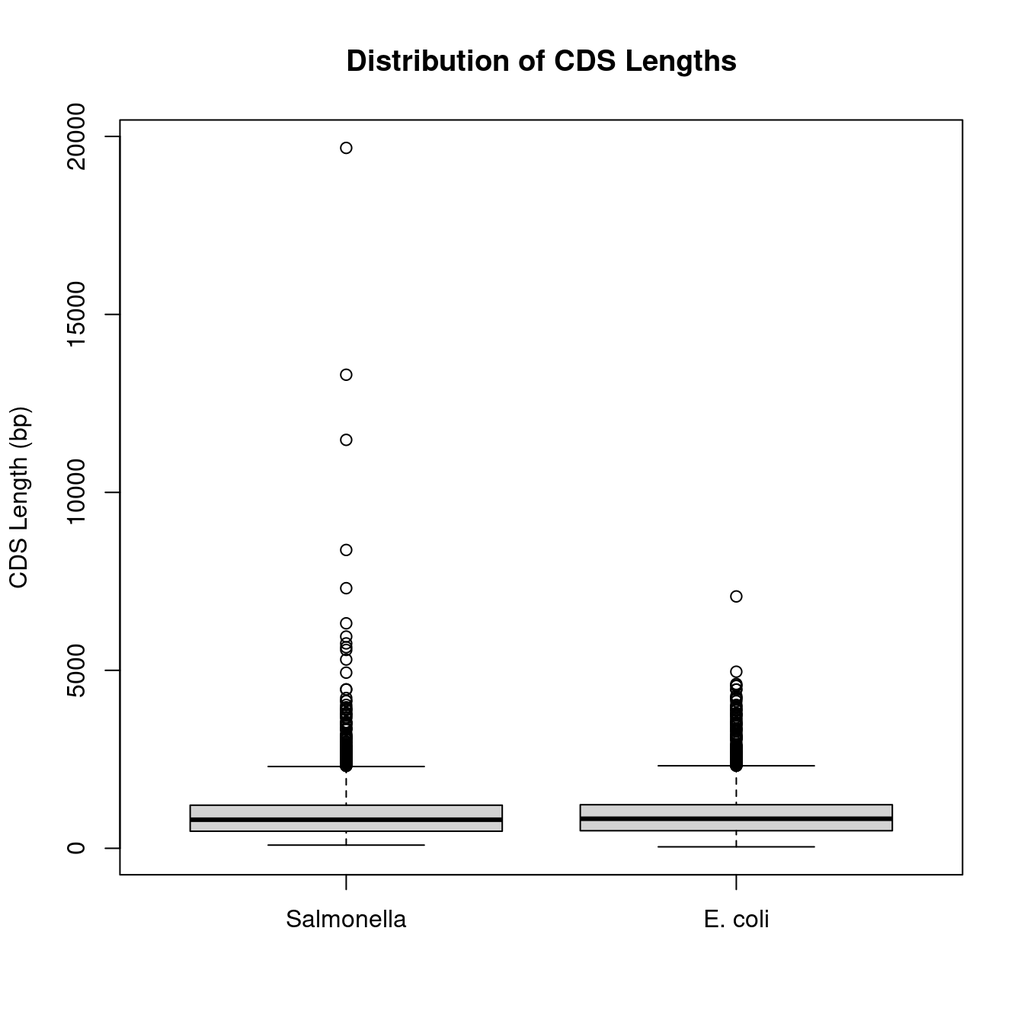

```r
# Q3: Boxplot of CDS lengths + mean/median table  =
boxplot(len_sal, len_ecoli,
        names = c("Salmonella", "E. coli"),
        ylab = "CDS Length (bp)",
        main = "Distribution of CDS Lengths")
```

#I computed summary stats for CDS lengths in both organisms. The table shows the mean CDS length is almost the same ~936.7 bp for Salmonella and ~938.6 bp for E. coli—and I also included the median column.The means being slightly higher than the medians reflects the right-skewed distributions with a few very long CDS, consistent with the boxplot.

```r
length_stats <- data.frame(
  Organism = c("Salmonella Weltevreden", "E. coli MG1655"),
  Mean_CDS_Length   = c(mean(len_sal), mean(len_ecoli)),
  Median_CDS_Length = c(median(len_sal), median(len_ecoli))
)
length_stats
```

```
##                 Organism Mean_CDS_Length Median_CDS_Length
## 1 Salmonella Weltevreden        936.7178               804
## 2         E. coli MG1655        938.5534               831
```

#Q4/5 I tallied nucleotide counts across all CDS with table(unlist(…)) and plotted them; both organisms show a modest GC bias—g (and c) are a bit higher than a/t. I then translated every CDS using the bacterial code (11) and plotted amino-acid frequencies. As expected for GC-rich bacteria, Leu (L) is most common, with Ala (A), Gly (G), Val (V), Ser (S) also high; Trp (W) and Cys (C) are among the rarest, and the stop (*) count is small. The overall profiles are very similar between Salmonella and E. coli, with Salmonella showing a slightly stronger GC/GC-codon signal.

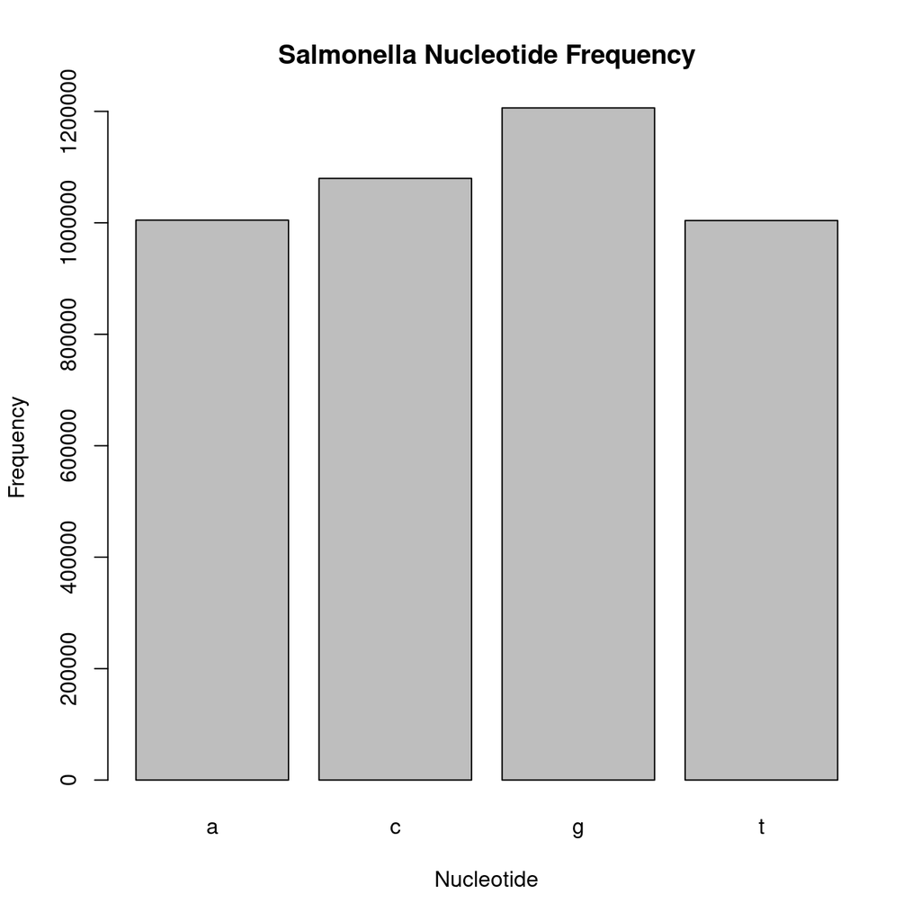

```r
# Q4/Q5: Nucleotide and amino acid frequencies

# DNA composition (nucleotide frequency)
barplot(table(unlist(cds_sal)),
        main = "Salmonella Nucleotide Frequency",
        xlab = "Nucleotide", ylab = "Frequency")
```

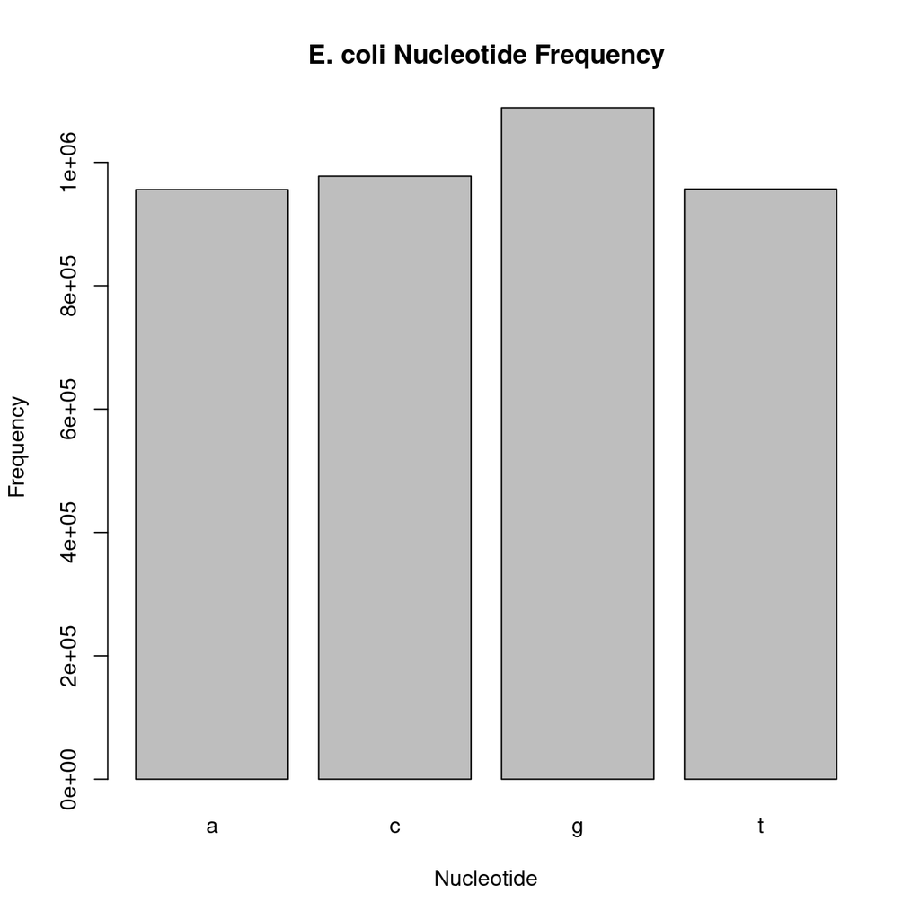

```r
barplot(table(unlist(cds_ecoli)),
        main = "E. coli Nucleotide Frequency",
        xlab = "Nucleotide", ylab = "Frequency")
```

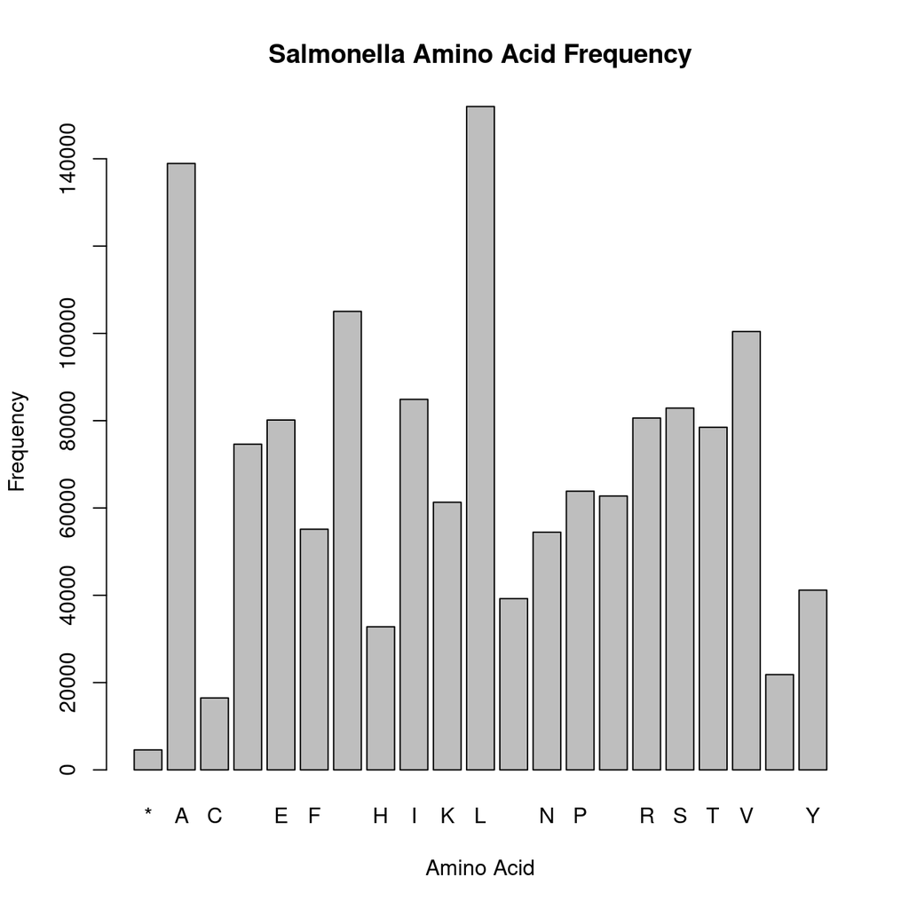

```r
# Translate with bacterial code using namespaced seqinr::translate
prot_sal   <- lapply(cds_sal,   function(x) seqinr::translate(x, numcode = 11))
prot_ecoli <- lapply(cds_ecoli, function(x) seqinr::translate(x, numcode = 11))

# Amino acid composition
barplot(table(unlist(prot_sal)),
        main = "Salmonella Amino Acid Frequency",
        xlab = "Amino Acid", ylab = "Frequency")
```

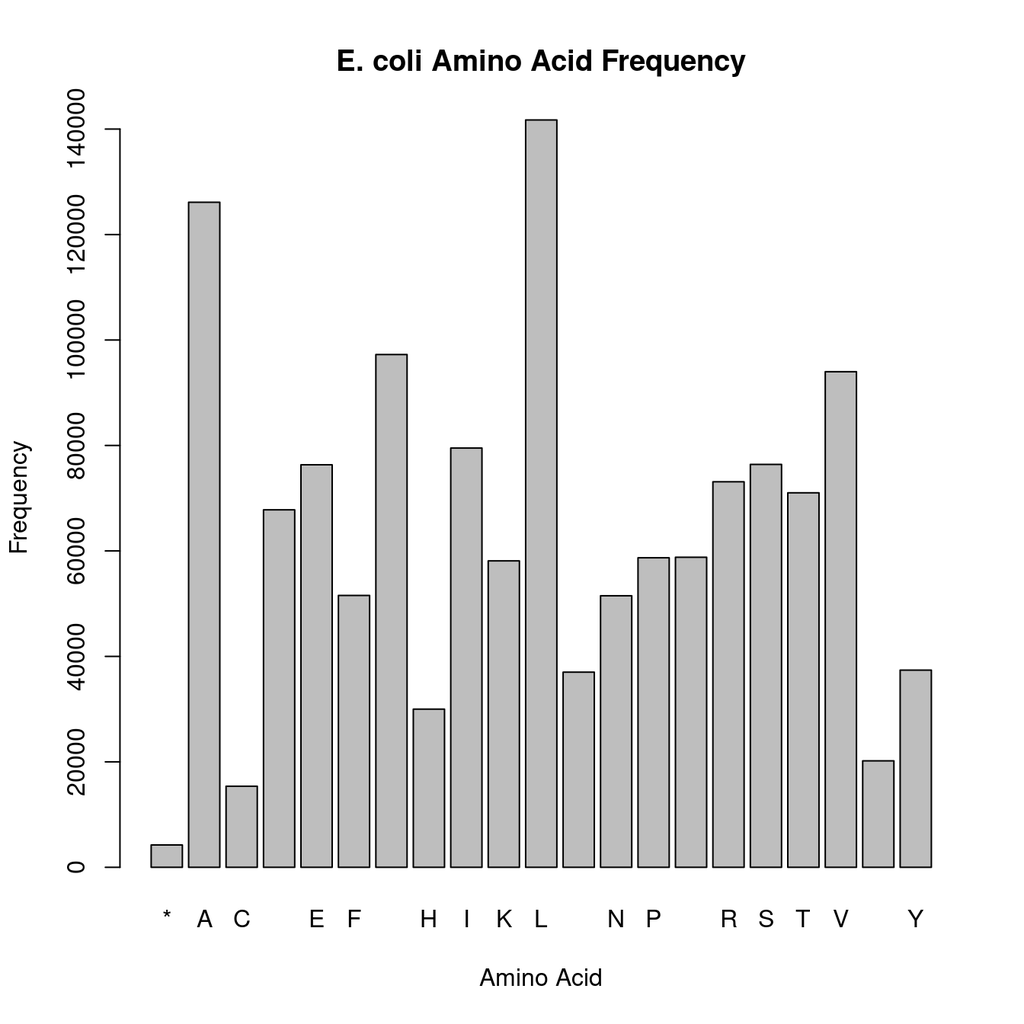

```r
barplot(table(unlist(prot_ecoli)),
        main = "E. coli Amino Acid Frequency",
        xlab = "Amino Acid", ylab = "Frequency")
```

#Q6 I ranked codon usage by RSCU and saw a clear GC bias in both genomes: CTG (Leu) is the top codon, with many other favored G/C-ending codons (CGC, CCG, GGC). Comparing amino-acid k-mers (k=3–5) between Salmonella and E. coli, I found the most common motifs are rich in Leu and Ala (e.g., LLA, ALAA, LLLAL), while the rarest combinations include infrequent residues like Trp, Cys, His, or Tyr. Across all plots the two species closely match, indicating similar codon preferences and local amino-acid composition, with only minor differences at the extremes. I think the different levels come from a mix of forces. First, both genomes are moderately GC-rich, so G/C-ending codons naturally arise more often and persist, boosting RSCU for codons like CTG/CGC/CCG/GGC. Second, translation selection matters: highly expressed genes prefer codons that match abundant tRNAs, so if tRNA^Leu(CAG) is plentiful, CTG (Leu) wins. Third, protein chemistry shapes k-mers—Leu and Ala are cheap, hydrophobic, and helix-friendly, so L/A-rich motifs are common, while costly or reactive residues (Trp, Cys, His, Tyr) are rarer. mRNA-level constraints (avoiding strong secondary structures or problematic motifs) and codon-pair/dipeptide kinetics also bias which sequences are favored. Finally, lineage history and horizontal gene transfer introduce species-specific codon signatures. Overall, shared GC content and translational ecology explain the similarity, while tRNA pools, expression programs, structural demands, and HGT create the subtle differences.

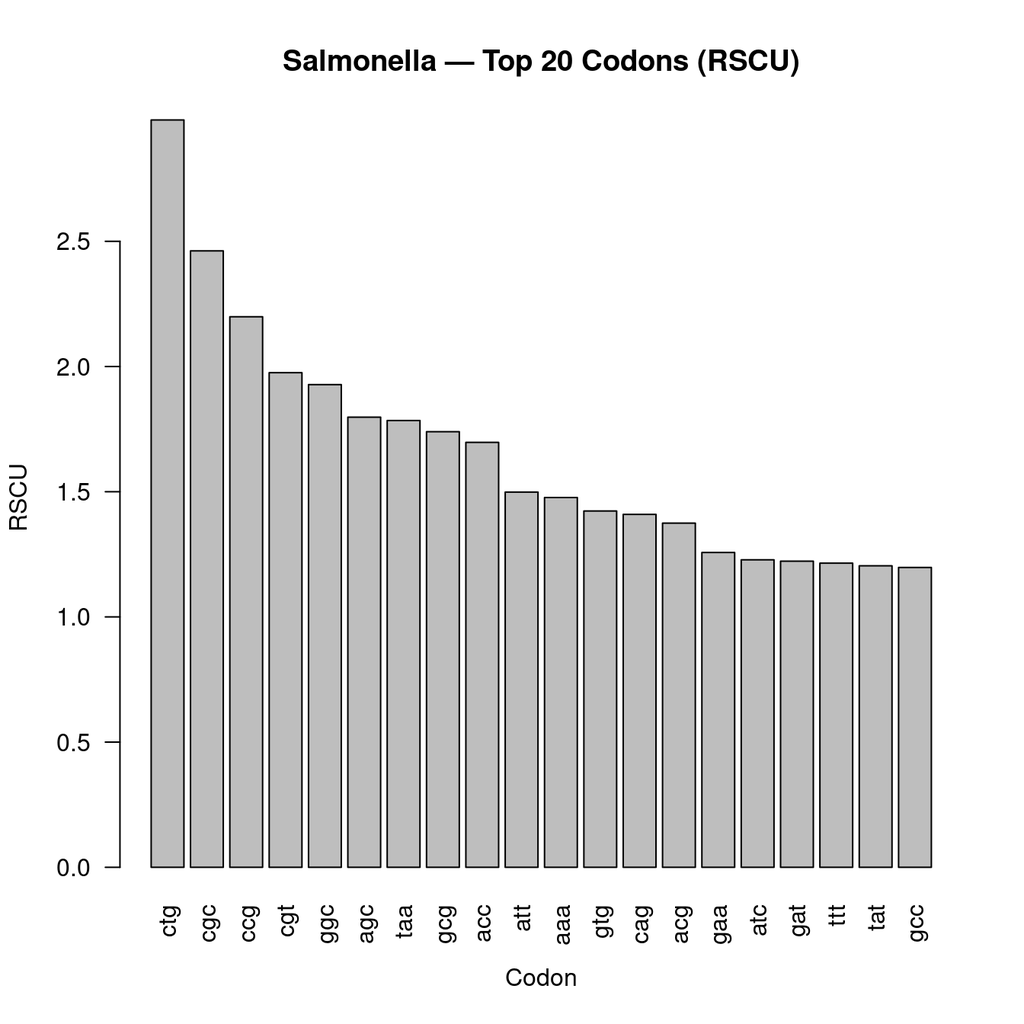

```r
# Q6: Codon usage — counts ("eff") and RSCU
codon_usage_sal_counts   <- seqinr::uco(unlist(cds_sal),   index = "eff")
codon_usage_ecoli_counts <- seqinr::uco(unlist(cds_ecoli), index = "eff")

rscu_sal   <- seqinr::uco(unlist(cds_sal),   index = "rscu")
rscu_ecoli <- seqinr::uco(unlist(cds_ecoli), index = "rscu")

# Top 20 by RSCU
barplot(sort(rscu_sal,   decreasing = TRUE)[1:20],
        las = 2, xlab = "Codon", ylab = "RSCU",
        main = "Salmonella — Top 20 Codons (RSCU)")
```

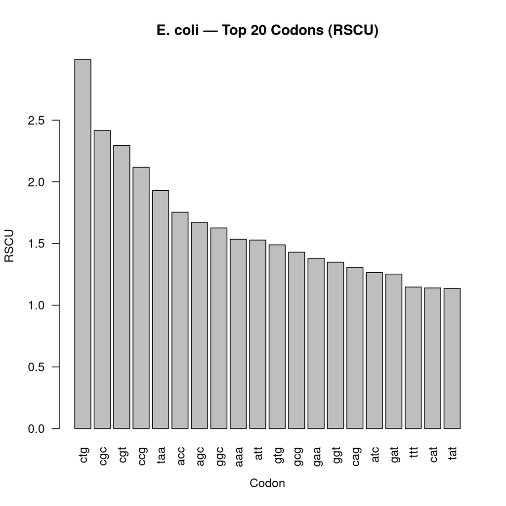

```r
barplot(sort(rscu_ecoli, decreasing = TRUE)[1:20],
        las = 2, xlab = "Codon", ylab = "RSCU",
        main = "E. coli — Top 20 Codons (RSCU)")
```

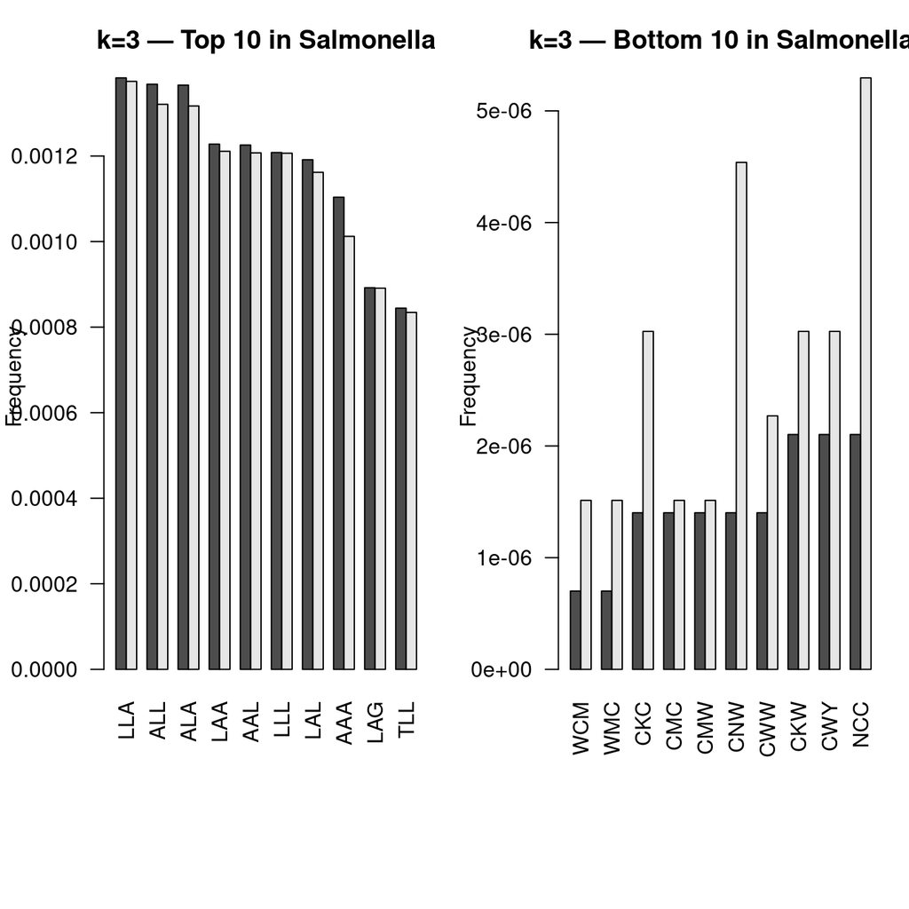

```r
# ---- Protein k-mer analysis: Salmonella vs E. coli (k = 3, 4, 5)
# Using seqinr + base R.

# 1) Ensure translated proteins exist
if (!exists("prot_sal") || !exists("prot_ecoli")) {
  prot_sal   <- lapply(cds_sal,   function(x) seqinr::translate(x, numcode = 11))
  prot_ecoli <- lapply(cds_ecoli, function(x) seqinr::translate(x, numcode = 11))
}

# 2) Remove stop codons '*' and flatten to single AA vectors
prot_sal   <- lapply(prot_sal,   function(v) v[v != "*"])
prot_ecoli <- lapply(prot_ecoli, function(v) v[v != "*"])
prots_sal   <- unlist(prot_sal)
prots_ecoli <- unlist(prot_ecoli)

# 3) Explicit 20-AA alphabet
AA <- strsplit("ACDEFGHIKLMNPQRSTVWY", "")[[1]]

# 4) Helper
aa_kmer_freq <- function(aa_vec, k) {
  seqinr::count(aa_vec, wordsize = k, alphabet = AA, freq = TRUE)
}

# 5) For each k in 3:5, pick Salmonella’s top/bottom 10 and compare to E. coli
analyze_k <- function(k) {
  freq_sal   <- aa_kmer_freq(prots_sal,   k)
  freq_ecoli <- aa_kmer_freq(prots_ecoli, k)

  if (length(freq_sal) == 0) return(invisible(NULL))

  # Top 10 (by Salmonella)
  top10    <- sort(freq_sal, decreasing = TRUE)[1:min(10, sum(freq_sal > 0))]
  bottom10 <- sort(freq_sal, decreasing = FALSE)[1:min(10, length(freq_sal))]

  # Align on the same k-mer names for comparison
  comp_top <- rbind(Salmonella = freq_sal[names(top10)],
                    `E. coli`  = freq_ecoli[names(top10)])
  comp_bottom <- rbind(Salmonella = freq_sal[names(bottom10)],
                       `E. coli`  = freq_ecoli[names(bottom10)])

  # Plots
  op <- par(no.readonly = TRUE); par(mfrow = c(1,2), mar = c( nine <- 9, 4, 3, 1))
  barplot(comp_top, beside = TRUE, las = 2, ylab = "Frequency",
          main = paste0("k=", k, " — Top 10 in Salmonella"))
  barplot(comp_bottom, beside = TRUE, las = 2, ylab = "Frequency",
          main = paste0("k=", k, " — Bottom 10 in Salmonella"))
  par(op)

  invisible(list(k = k, top = top10, bottom = bottom10,
                 comp_top = comp_top, comp_bottom = comp_bottom))
}

res_k3 <- analyze_k(3)
```

```r
res_k4 <- analyze_k(4)
```

[figure not shown]

```r
res_k5 <- analyze_k(5)
```

[figure not shown]